# Model and Analysis

Lawson et al.

2023-06-19

# II. Define functions

Define function where variable is either `x` i.e population stock, or `s` i.e price paid to poachers. All the parameters take default values specified in the global environment.

Functions for the baseline model are :

- `growth(x, ...)` : logistic growth function, yields growth of population (in metric tons)
- `open_access(x,...)`: harvest (in metric tons) when fishery is in open-access
- `pt_harvest(x,...)` : harvest (in metric tons) when trader controls the upstream market and operates on a competitive downstream market (i.e., she is price taker)
- `monop_harvest(x, ...), monop_harvest_lq(x, ...)`: harvest (in metric tons) when trader is a monopolist in the quadratic and linear quadratic cost models.

Then, once aquaculture is introduced :

- `oa_aqua(x, ...)`: harvest (in metric tons) in the open access fishery following the introduction of aquaculture
- `comp_aqua(x, ...)` : harvest (in metric tons) when a trader controls the upstream market and operates on a competitive downstream market, following the introduction of aquaculture.
- `cournot_harvest(x, ...)`, `bertrand_harvest(x, ...), cournot_harvest_lq(x, ...)`, `bertrand_harvest_lq(x, ...)`: harvest (in metric tons) when trader and farmer compete in *Cournot*, i.e, set quantities strategically, and *Bertrand*, i.e, set prices strategically in the quadratic and linear quadratic cost models.
- `price_poachers_cournot(x, ...)`, `price_poachers_bertrand(x, ...)`: price paid to poachers (in USD/metric tons) when trader and farmer compete in *Cournot* and *Bertrand*
- `cournot_farmed(s, ...)`, `bertrand_farmed(s, ...)`: quantity farmed (in metric tons) when trader and farmer compete in *Cournot* and *Bertrand*

# III. Generate results

## A. Quadratic model

Generate results saved at `~/data/outputs/result1.csv`.

```
##   x    growth  open_access        oa_aqua     ss_oa ss_oa_aqua    pt_harvest
## 1 1 0.2012727 0.0001493663 0.000006158481 0.2011234  0.2012666 0.00007468313
## 2 2 0.4025256 0.0005974647 0.000024633925 0.4019281  0.4025009 0.00029873246
## 3 3 0.6037585 0.0013442947 0.000055426330 0.6024142  0.6037031 0.00067214779
## 4 4 0.8049715 0.0023898549 0.000098535698 0.8025817  0.8048730 0.00119492880
## 5 5 1.0061646 0.0037341434 0.000153962028 1.0024305  1.0060107 0.00186707505
## 6 6 1.2073379 0.0053771580 0.000221705321 1.2019607  1.2071161 0.00268858595
##       ss_pt      comp_aqua ss_comp_aqua monop_harvest  ss_monop cournot_harvest
## 1 0.2011981 0.000003079241    0.2012697  0.0001493662 0.2011234   0.00008492275
## 2 0.4022268 0.000012316962    0.4025132  0.0005974644 0.4019281   0.00033969075
## 3 0.6030863 0.000027713165    0.6037308  0.0013442930 0.6024142   0.00076430332
## 4 0.8037766 0.000049267849    0.8049222  0.0023898494 0.8025817   0.00135875928
## 5 1.0042976 0.000076981014    1.0060877  0.0037341300 1.0024305   0.00212305699
## 6 1.2046493 0.000110852660    1.2072270  0.0053771302 1.2019607   0.00305719436
##   price_poachers_cournot cournot_farmed ss_cournot bertrand_harvest
## 1               924375.6       498.4175  0.2011878    0.00004105786
## 2               924375.0       498.4174  0.4021859    0.00016423139
## 3               924373.9       498.4172  0.6029942    0.00036952049
## 4               924372.5       498.4170  0.8036128    0.00065692497
## 5               924370.5       498.4166  1.0040416    0.00102644459
## 6               924368.2       498.4162  1.2042807    0.00147807902
##   price_poachers_bertrand bertrand_farmed ss_bertrand
## 1                446910.7        837.6766   0.2012317
## 2                446910.6        837.6765   0.4023613
## 3                446910.4        837.6763   0.6033890
## 4                446910.2        837.6761   0.8043146
## 5                446909.9        837.6758   1.0051382
## 6                446909.5        837.6755   1.2058598
```

Use `result1` to produce steady states:

| Market structure | Stock | Harvest | Farmed |
| --- | --- | --- | --- |
| Open access - before | 1799 | 329.9835 | NA |
| Open access - before | 6646 | 898.1595 | NA |
| Open access - before | 11783 | 990.0655 | NA |
| Open access - aquaculture | 12495 | 961.4930 | NA |
| Price taker - before | 12606 | 955.9557 | NA |
| Price taker - aquaculture | 15447 | 734.7370 | NA |
| Monopoly | 17230 | 513.8276 | NA |
| Cournot | 18208 | 365.7974 | 333.8087 |
| Betrand | 17072 | 535.9869 | 432.3084 |

With a realistic market structure, i.e, full control over the value chain by the trader :

1. **Monopoly scenario** with cost parameter c=0 is a 36.68, % variation in *population stock* in tonnes (compared to price taker) or, equivalently, of 179922 adult totoabas and a difference of 442.13(in tons) in *harvest* or, equivalently, of 17203 adult totoabas
2. **Worst case scenario** after aquaculture is introduced, with cost parameter c=0 is a -0.92 % variation in *population stock* in tonnes or, equivalently, of -6148 adult totoabas, and a difference of 22.16 (tons) in *harvest* or, equivalently, of -862.23 adult totoabas
3. **Best case scenario** with cost parameter c=0 is a 5.68 % variation in *population stock* in tonnes or, equivalently, of 38054.47 adult totoabas and a difference of -148.03 ( tons) in *harvest* or, equivalently, of 5759.93 adult totoabas

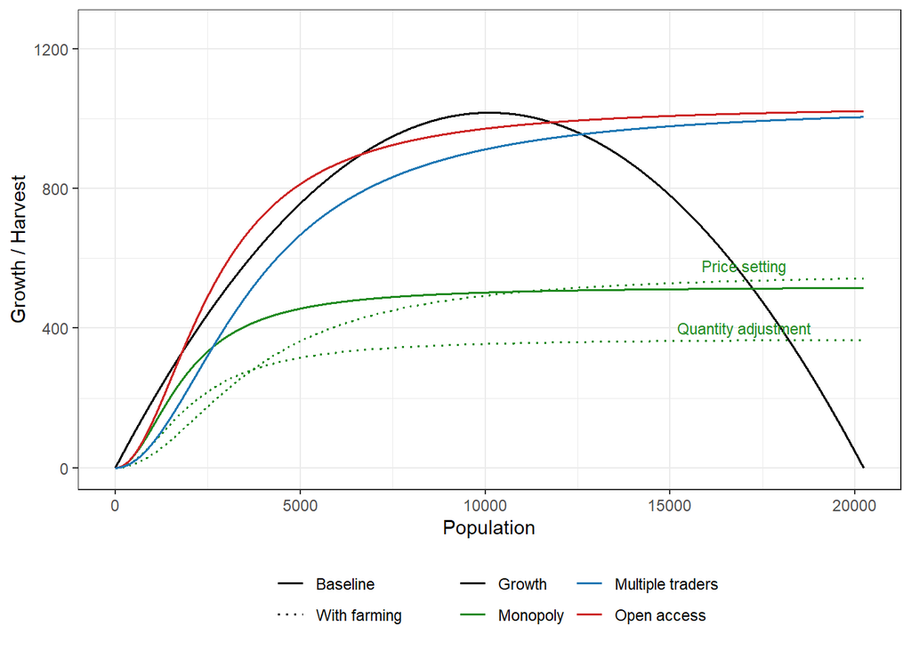

## Fishing effort evolution

| Stock | Harvest | Farmed | Market structure | effort |
| --- | --- | --- | --- | --- |
| 1799 | 329.9835 | NA | Open access - before | 9157.217 |
| 6646 | 898.1595 | NA | Open access - before | 6746.764 |
| 11783 | 990.0655 | NA | Open access - before | 4194.792 |
| 12495 | 961.4930 | NA | Open access - aquaculture | 3841.601 |
| 12606 | 955.9557 | NA | Price taker - before | 3785.846 |
| 15447 | 734.7370 | NA | Price taker - aquaculture | 2374.598 |
| 17230 | 513.8276 | NA | Monopoly | 1488.794 |
| 18208 | 365.7974 | 333.8087 | Cournot | 1002.953 |
| 17072 | 535.9869 | 432.3084 | Betrand | 1567.372 |